# Airway RNA-seq Differential Expression Analysis

- Show All Code
- Hide All Code
- View Source

Dexamethasone-treated vs Untreated Human Airway Smooth Muscle Cells

Author

Petros Kogios

Published

May 15, 2026

## Executive Summary

Differential expression analysis was performed on RNA-seq data from the *airway* dataset (Himes et al., 2014; PMID 24926665) to characterize transcriptomic changes associated with dexamethasone treatment in primary human airway smooth muscle (HASM) cells. A total of 16,596 genes were evaluated across eight samples derived from four cell lines exposed to either 1 µM dexamethasone or vehicle control for 18 hours, using a paired experimental design that accounted for inter-individual variation. Of the genes tested, 4,099 (24.7%) were identified as statistically significant differentially expressed genes (DEGs) at an adjusted p-value threshold of 0.05, with 2,201 genes exhibiting upregulation and 1,898 exhibiting downregulation in the treated condition relative to the untreated control. Principal component analysis revealed that PC1 and PC2 collectively explained 72% of the total variance in the dataset (48% and 24%, respectively), suggesting that treatment condition was a dominant source of transcriptional variability across samples.

## Results Interpretation

The magnitude and breadth of the differential expression response were consistent with the well-characterized pleiotropic activity of glucocorticoid receptor signaling in airway smooth muscle cells. Among the five genes exhibiting the most extreme statistical evidence for differential expression, DUSP1 (dual specificity phosphatase 1; log2FC = 2.95, padj = 1.22 × 10⁻¹²⁴) was notable as an established glucocorticoid-responsive gene, lending biological plausibility to the overall findings. SPARCL1, encoding a secreted extracellular matrix-associated protein, displayed the largest observed fold change among the top-ranked genes (log2FC = 4.57, padj = 3.58 × 10⁻¹³²), while SAMHD1, a deoxynucleoside triphosphohydrolase, demonstrated both high statistical confidence and substantial mean expression (baseMean = 12,718), indicating robust signal detection for this transcript. CACNB2 (log2FC = 3.29) and MAOA (log2FC = 3.35) were also among the most statistically significant upregulated transcripts, pointing toward dexamethasone-associated remodeling of calcium channel regulatory components and monoaminergic enzymatic activity, respectively, though functional interpretation of these associations requires corroboration beyond transcriptomic evidence alone. It should be noted that large log2 fold changes in this dataset reflect statistical effect sizes estimated from a relatively small number of replicates; high fold change values do not independently establish biological importance in the absence of functional validation.

## Limitations

Several important limitations should be considered when interpreting these findings. The analysis was conducted on a small sample size of eight libraries derived from four donors, which, while sufficient to detect large-magnitude expression differences with high statistical confidence, may result in imprecision in fold change estimates for genes with moderate or low expression levels. Adjusted p-values of the magnitude reported here (approaching 10⁻¹³²) should be interpreted cautiously, as they reflect both true biological signal and the particularly favorable signal-to-noise ratio afforded by the paired design rather than necessarily indicating that reported genes are more biologically consequential than others not meeting the significance threshold. Furthermore, the single time point examined (18 hours) and single dose of dexamethasone (1 µM) preclude conclusions regarding the temporal dynamics or dose-dependency of the observed transcriptional associations.

Transcriptomic data of this nature are observational with respect to mechanism; the identification of differentially expressed genes establishes statistical association with treatment condition but does not demonstrate that dexamethasone directly regulates any individual gene, nor does it address post-transcriptional, translational, or protein-level changes. Results are specific to primary HASM cells and may not generalize to other cell types or in vivo airway tissue contexts. Functional enrichment analyses and orthogonal experimental validation would be necessary to translate the identified gene lists into mechanistic or therapeutic insights.

## Dataset

`airway` Bioconductor package (Himes et al. 2014, PMID: 24926665).

- **Samples**: 8 RNA-seq libraries
- **Cell lines**: 4 primary human ASM cultures (N052611, N061011, N080611, N61311)
- **Conditions**: untreated (`untrt`) vs 1 µM dexamethasone for 18h (`trt`)
- **Design**: paired (each cell line measured under both conditions)

## Methods

We fit a negative binomial generalized linear model with DESeq2 (v1.46) using the design formula `~ cell + dex`. The `cell` covariate controls for inter-individual variability across the 4 primary cultures. We used the Wald test with the contrast `trt vs untrt` and Benjamini-Hochberg correction. Significance threshold: padj < 0.05.

Pre-filtering retained genes with ≥10 reads in ≥3 samples (63,677 → 16,596 genes).

## Results

### Sample-level QC

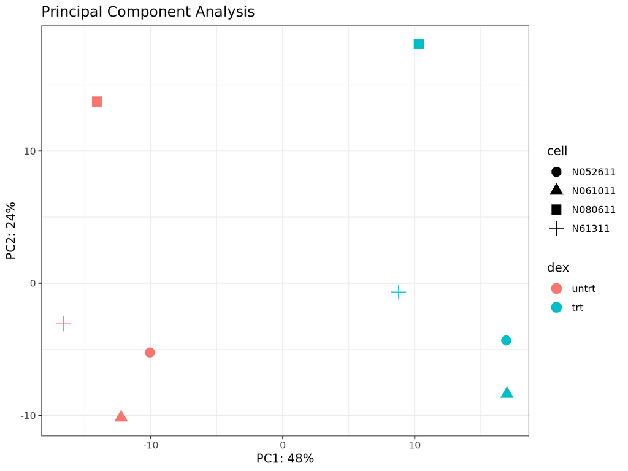

```r
pca_data <- plotPCA(vsd, intgroup = c("dex", "cell"), returnData = TRUE)
pv <- round(100 * attr(pca_data, "percentVar"))

ggplot(pca_data, aes(PC1, PC2, color = dex, shape = cell)) +
  geom_point(size = 4) +
  xlab(paste0("PC1: ", pv[1], "%")) +
  ylab(paste0("PC2: ", pv[2], "%")) +
  theme_bw() +
  ggtitle("Principal Component Analysis")
```

### Summary table

```r
summary_df <- data.frame(
  Metric = c("Genes tested", "Significant DEGs (padj < 0.05)",
             "Upregulated", "Downregulated"),
  Value = c(sum(!is.na(res$padj)),
            nrow(res_sig),
            sum(res_sig$log2FoldChange > 0),
            sum(res_sig$log2FoldChange < 0))
)
kable(summary_df)
```

| Metric | Value |
| --- | --- |
| Genes tested | 16596 |
| Significant DEGs (padj < 0.05) | 4099 |
| Upregulated | 2201 |
| Downregulated | 1898 |

### Volcano plot

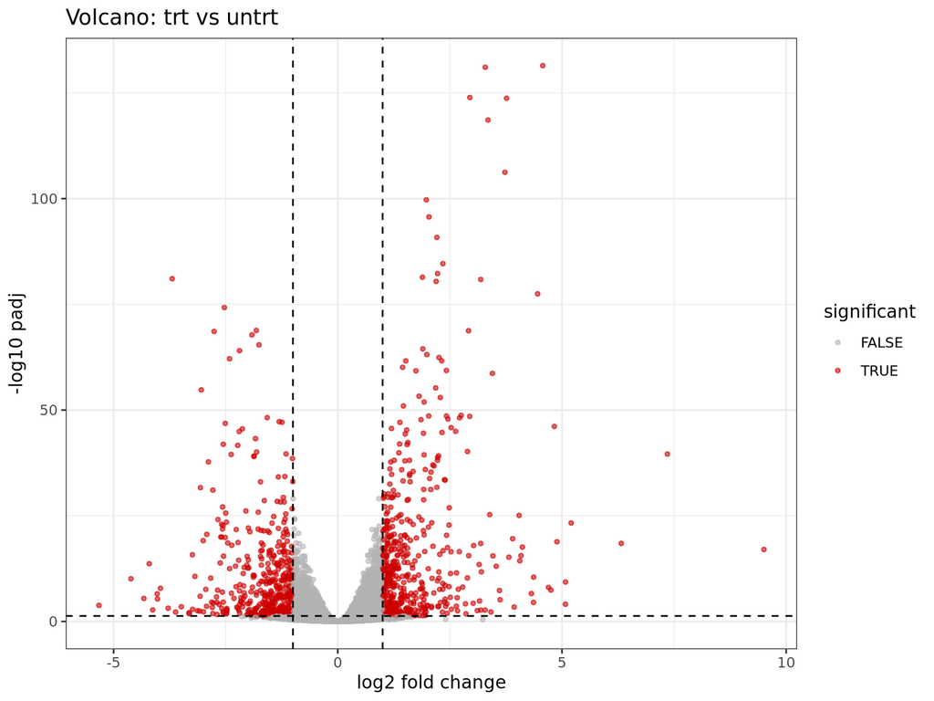

```r
res_df$significant <- with(res_df,
    !is.na(padj) & padj < 0.05 & abs(log2FoldChange) > 1)

ggplot(res_df, aes(log2FoldChange, -log10(padj), color = significant)) +
  geom_point(alpha = 0.6, size = 1) +
  scale_color_manual(values = c("grey70", "red3")) +
  geom_vline(xintercept = c(-1, 1), linetype = "dashed") +
  geom_hline(yintercept = -log10(0.05), linetype = "dashed") +
  theme_bw() +
  labs(title = "Volcano: trt vs untrt",
       x = "log2 fold change", y = "-log10 padj")
```

### Heatmap (top 30 DEGs)

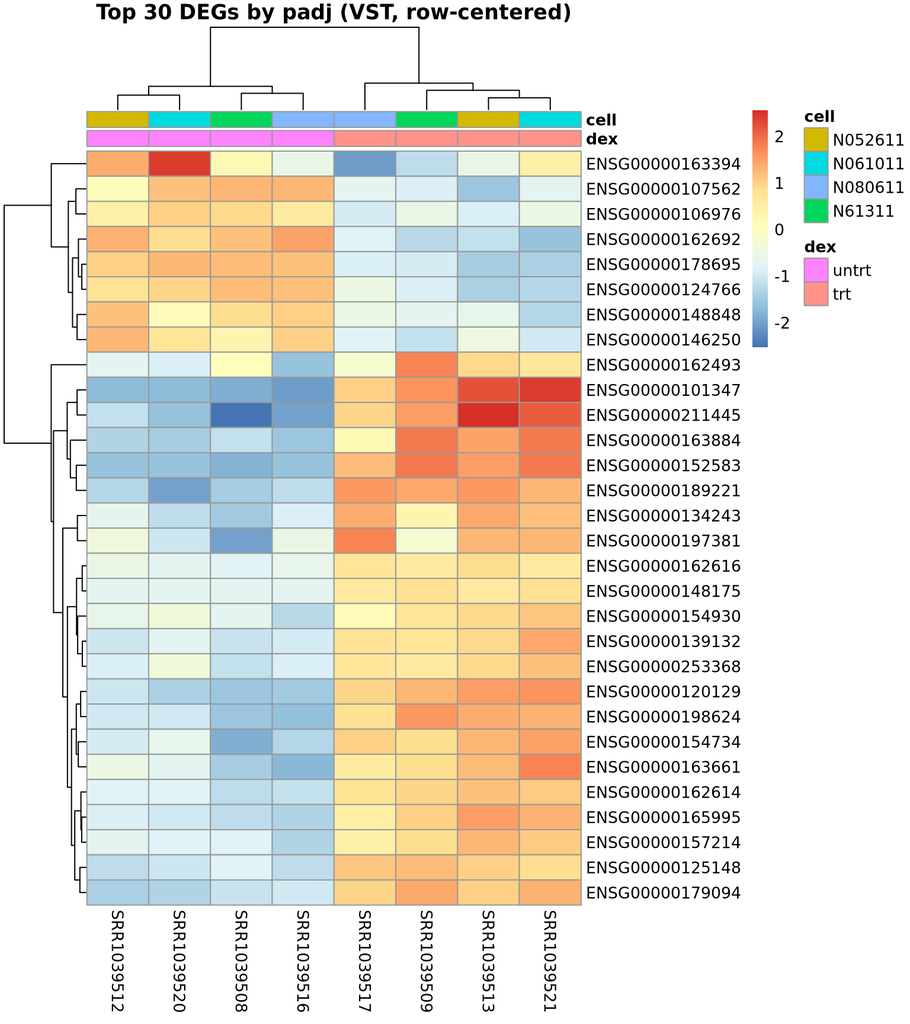

```r
top_genes <- head(rownames(res_sig), 30)
mat <- assay(vsd)[top_genes, ]
mat <- mat - rowMeans(mat)
anno <- as.data.frame(colData(vsd)[, c("dex", "cell")])
pheatmap(mat, annotation_col = anno, show_rownames = TRUE,
         main = "Top 30 DEGs by padj (VST, row-centered)")
```

### Top 10 DEGs

```r
top10 <- head(res_sig[, c("gene", "log2FoldChange", "padj", "baseMean")], 10)
kable(top10, digits = c(0, 2, 50, 1), row.names = FALSE,
      caption = "Top 10 DEGs ranked by adjusted p-value")
```

Top 10 DEGs ranked by adjusted p-value

| gene | log2FoldChange | padj | baseMean |
| --- | --- | --- | --- |
| ENSG00000152583 | 4.57 | 0 | 998.3 |
| ENSG00000165995 | 3.29 | 0 | 495.7 |
| ENSG00000120129 | 2.95 | 0 | 3413.0 |
| ENSG00000101347 | 3.76 | 0 | 12718.3 |
| ENSG00000189221 | 3.35 | 0 | 2344.1 |
| ENSG00000211445 | 3.73 | 0 | 12303.0 |
| ENSG00000157214 | 1.97 | 0 | 3013.5 |
| ENSG00000162614 | 2.03 | 0 | 5400.1 |
| ENSG00000125148 | 2.21 | 0 | 3660.2 |
| ENSG00000154734 | 2.34 | 0 | 30352.2 |

## Reference

Himes BE et al. *RNA-Seq Transcriptome Profiling Identifies CRISPLD2 as a Glucocorticoid Responsive Gene that Modulates Cytokine Function in Airway Smooth Muscle Cells.* PLoS One. 2014;9(6):e99625.